# Sampling points in polygons and creatign climatic clusters

Mathew Rees

20/05/2024

# 1 Libraries

```r
library(tidyverse)
library(tidyterra)
library(sf)
library(sp)
library(raster)
library(RStoolbox)
library(rnaturalearth)
library(geodata)
library(viridis)
library(ade4)
library(factoextra)
```

# 2 Import polygons

First we want to import a shapefile containing a polygon of the region of interest (ROI).

You can use this tool to define the ROI: https://www.openstreetmap.org/export#map=6/2.460/120.256

```r
Borneo_island <- ne_countries(scale="medium", returnclass = "sf") %>%
  filter(admin %in% c("Indonesia", "Malaysia", "Brunei"))

ROI = c(xmin= 108.699, xmax = 119.355, ymin = -4.127, ymax = 7.580)
```

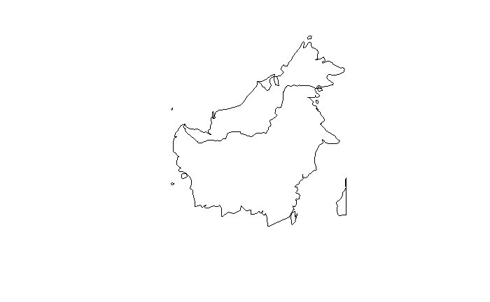

```r
Borneo <- st_crop(Borneo_island, st_bbox(ROI))
Borneo_sfc <- Borneo %>% st_as_sfc()
plot(Borneo_sfc)
```

Next I want to crop out the little part of West Sulawesi.

```r
cropped_extent <- c(xmin= 118, xmax = 119.355 , ymin = -4.144604, ymax = -1) %>% st_bbox() %>% st_as_sfc()
st_crs(cropped_extent) <- st_crs(Borneo_sfc)
```

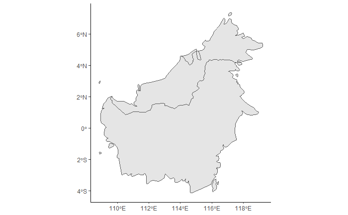

```r
Borneo_sf <- st_difference(Borneo_sfc, cropped_extent) %>% st_as_sf()
ggplot() + geom_sf(data=Borneo_sf) + theme_classic()
```

Great. Now we can simply merge the outline of all three countries

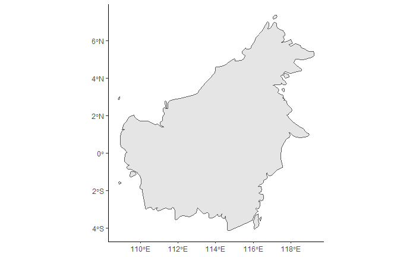

```r
Borneo_united <- st_union(Borneo_sf)
ggplot() + geom_sf(data=Borneo_united) + theme_classic()
```

# 3 Sampling points

Let’s make some random sampling points that cover the island.

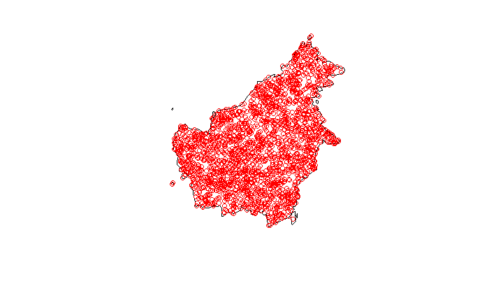

```r
p1 = st_sample(Borneo_united, 2000)
plot(st_geometry(Borneo_united))
plot(p1, add = TRUE, col="red")
```

Here are 2000 random sample points from Borneo. You can create as many or as few as you like.

```r
sample_pts<-as(p1, "Spatial") %>% coordinates() %>% `colnames<-`(c("longitude", "latitude")) %>% as.data.frame()
head(sample_pts)
```

|  | longitude | latitude |
| --- | --- | --- |
| 1 | 110.9534 | -2.3031352 |
| 2 | 115.6369 | 2.8255033 |
| 3 | 116.9255 | 1.7259102 |
| 4 | 118.5835 | 5.3207058 |
| 5 | 114.0413 | -0.1591454 |
| 6 | 114.0770 | 0.7191741 |

# 4 Bioclim variables

We can download Bioclim variables for our ROI

```r
bio <- worldclim_global(var = "bio", # "tmin", "tmax", "tavg", "prec", "wind", "vapr", or "bio"
                        res = 5, # resolution: 10, 5, 2.5, or 0.5 (minutes of a degree)
                        path = "./wc")
```

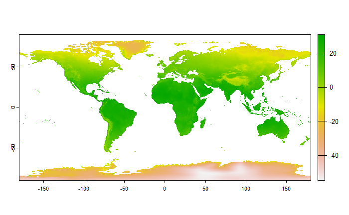

```r
plot(bio[[1]])
```

First, let’s crop our `bio` object to the ROI.

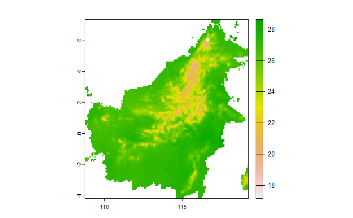

```r
bio_cropped <- crop(bio, Borneo_sf)
plot(bio_cropped[[1]])
```

# 5 RasterPCA

We can use the RSToolbox to build a PCA of Climate space

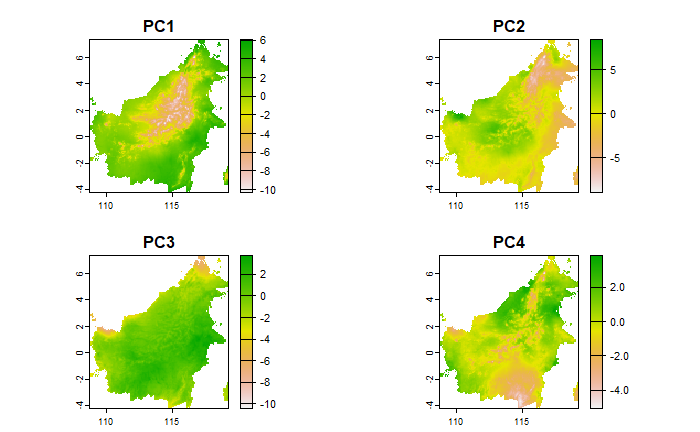

```r
bio_PCA <- rasterPCA(bio_cropped, nSamples = NULL, spca = T, maskCheck = T)

plot(bio_PCA$map[[1:4]])
```

See the variance explained by the PCA axes

```r
summary(bio_PCA$model)
```

```
Importance of components:
                          Comp.1    Comp.2    Comp.3    Comp.4     Comp.5     Comp.6      Comp.7
Standard deviation     2.9790985 2.0846479 1.6277872 1.3612626 0.74581779 0.65444981 0.334651670
Proportion of Variance 0.4671067 0.2287240 0.1394574 0.0975282 0.02927601 0.02254235 0.005894302
Cumulative Proportion  0.4671067 0.6958308 0.8352882 0.9328164 0.96209242 0.98463476 0.990529064
                            Comp.8      Comp.9     Comp.10      Comp.11      Comp.12      Comp.13
Standard deviation     0.311894015 0.179795885 0.138341541 0.1093683488 0.0919293625 0.0724375561
Proportion of Variance 0.005119888 0.001701398 0.001007283 0.0006295492 0.0004447899 0.0002761684
Cumulative Proportion  0.995648952 0.997350350 0.998357633 0.9989871824 0.9994319723 0.9997081407
                          Comp.14      Comp.15      Comp.16      Comp.17      Comp.18      Comp.19
Standard deviation     0.06053380 3.496889e-02 2.125760e-02 1.166429e-02 8.379815e-03 8.850505e-08
Proportion of Variance 0.00019286 6.435913e-05 2.378346e-05 7.160824e-06 3.695858e-06 4.122707e-16
Cumulative Proportion  0.99990100 9.999654e-01 9.999891e-01 9.999963e-01 1.000000e+00 1.000000e+00
```

So the first Axis explains 46.7%, the second 22.8%, third 13.9% and fourth 9.7%. Together they make up 93% of variance.

We can try to use a very simple k-means classifier with a predefined number of categories. Let’s say 9.

See here : https://bleutner.github.io/RStoolbox/reference/unsuperClass.html

```r
## Run classification
set.seed(12345)
unC <- unsuperClass(bio_PCA$map[[1:3]], nSamples = 10000, nClasses = 9, nStarts = 25)
unC
```

```
unsuperClass results

*************** Model ******************
$model
K-means clustering with 9 clusters of sizes 643, 326, 218, 1009, 242, 739, 779, 940, 446

Cluster centroids:
         PC1        PC2        PC3
1 -4.4560533  0.3836639  0.3943814
2 -1.1488400 -3.7820641 -1.3877558
3  1.8278246  2.3998803 -4.6491370
4  1.4576005  0.2154038  1.3376434
5 -7.2716383 -3.0099929 -0.4636505
6  3.0278721 -0.7146978 -0.7178394
7 -1.3339619  2.3544369  0.8175310
8  0.5079033  0.8833738 -0.9418565
9  3.1076556 -2.5483376  1.6919374

Within cluster sum of squares by cluster:
[1] 2120.833 1493.566 1946.948 1999.251 1507.656 2019.632 2016.218 2135.986 1181.333

*************** Map ******************
$map
class       : SpatRaster
dimensions  : 138, 126, 1  (nrow, ncol, nlyr)
resolution  : 0.08333333, 0.08333333  (x, y)
extent      : 108.75, 119.25, -4.166667, 7.333333  (xmin, xmax, ymin, ymax)
coord. ref. : lon/lat WGS 84 (EPSG:4326)
source(s)   : memory
name        : class_unsupervised
min value   :                  1
max value   :                  9
```

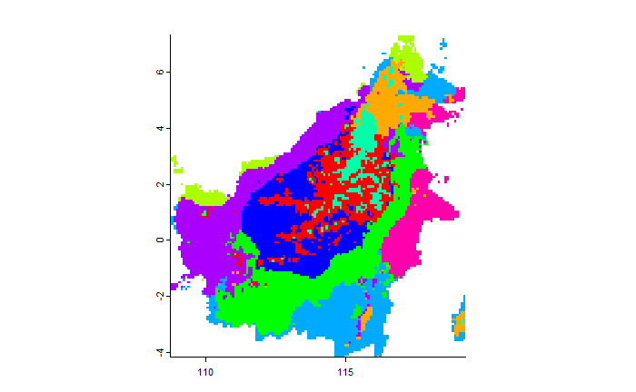

```r
## Plots
colors <- rainbow(9)
plot(unC$map, col = colors, legend = FALSE, axes = T, box = FALSE)
```

```r
##legend(1,1, legend = paste0("C",1:5), fill = colors, title = "Classes", horiz = TRUE,  bty = "n")
```

```r
## Return the distance of each pixel to each class centroid
unC2 <- unsuperClass(bio_PCA$map, nSamples = 10000, nClasses = 9, output = "distances")
unC2
```

```
unsuperClass results

*************** Model ******************
$model
K-means clustering with 9 clusters of sizes 317, 236, 525, 790, 684, 686, 709, 1050, 275

Cluster centroids:
         PC1        PC2        PC3          PC4        PC5         PC6          PC7         PC8
1 -1.1520754 -3.8230640 -1.3701026  0.235665699  0.6264822  0.06782037  0.150253293 -0.20251057
2  1.6394970  2.4573728 -4.3197763 -0.611559472 -0.6535356 -0.86388547  0.163443050  0.22889291
3  2.9904813 -2.3771845  1.4765707  0.736152713 -0.3879088 -0.58203233  0.011473159  0.10189672
4 -0.7774436  2.3978637  0.6366435 -0.019544115  0.4635223 -0.18774407  0.047512909 -0.09612790
5  3.1280314 -0.4109581 -0.1922338 -1.873147048  0.3713819  0.56508560 -0.137680150  0.15179884
6 -4.2225010  0.5967700  0.4018444  0.029101967 -0.1109414  0.16843088 -0.012854452  0.06435629
7  0.7000244  0.5081141 -1.0813588  1.931428912  0.0207521  0.39396936 -0.034820777 -0.01858853
8  1.1687482  0.2826857  0.8571249  0.001206062 -0.2933206 -0.04269775  0.007870029 -0.13179787
9 -7.2167287 -2.8096288 -0.4150134 -1.150341861 -0.2891791 -0.10530839 -0.090067067  0.13784742
           PC9         PC10         PC11          PC12         PC13         PC14          PC15
1 -0.040809709  0.127351766 -0.046985820 -0.0299809594  0.006922632 -0.015717457 -0.0012390259
2  0.037547336  0.172113900  0.041265155  0.0078855158  0.011145186 -0.009318544 -0.0013879010
3 -0.015375829 -0.035004878 -0.008779944  0.0269283880  0.020290112 -0.005363370 -0.0107749263
4 -0.032093559 -0.017697737  0.017506175 -0.0007356384  0.003626282 -0.009189899 -0.0006420425
5  0.001303500 -0.030114192  0.010372615 -0.0153746320 -0.002362428  0.002087639  0.0036315449
6  0.003386327 -0.037327958  0.025194544 -0.0019366246 -0.006620493  0.002160802 -0.0080339440
7  0.020114277 -0.028116495 -0.009514298  0.0018397001  0.015813563  0.010848800  0.0042242263
8  0.002776151  0.022942619 -0.019165702 -0.0037330900 -0.020589551  0.007044564  0.0046154530
9  0.037873411 -0.004431581  0.006534307  0.0122215043  0.007742772 -0.005145018 -0.0015844001
           PC16          PC17          PC18          PC19
1 -0.0045278922 -1.686884e-03  0.0008112996  3.466621e-15
2 -0.0106113687  9.369035e-04  0.0015188017  1.253271e-13
3  0.0020669600  3.281773e-03  0.0030110904  1.795696e-13
4 -0.0058041071  1.288981e-03 -0.0001447985  5.307660e-14
5  0.0081578680  3.966229e-04  0.0011917501  4.879027e-14
6  0.0014030583 -9.583368e-05  0.0012912709  2.486019e-14
7  0.0028209828 -8.550022e-05 -0.0010696398 -5.067320e-14
8 -0.0000744332 -2.405956e-03 -0.0017841720 -1.319736e-13
9  0.0003588533 -7.755529e-04 -0.0007667518 -6.236090e-14

Within cluster sum of squares by cluster:
[1] 2198.719 2651.480 2703.711 3328.491 3394.953 3346.239 3933.663 3820.025 2020.112

*************** Map ******************
$map
class       : SpatRaster
dimensions  : 138, 126, 9  (nrow, ncol, nlyr)
resolution  : 0.08333333, 0.08333333  (x, y)
extent      : 108.75, 119.25, -4.166667, 7.333333  (xmin, xmax, ymin, ymax)
coord. ref. : lon/lat WGS 84 (EPSG:4326)
source(s)   : memory
names       :    dist_c1,   dist_c2,   dist_c3,    dist_c4,    dist_c5,    dist_c6, ...
min values  :  0.8017101,  1.023381,  1.034012,  0.5449229,  0.6566483,  0.8658421, ...
max values  : 15.6422407, 16.859738, 16.507850, 16.0305885, 16.3279280, 15.2121998, ...
```

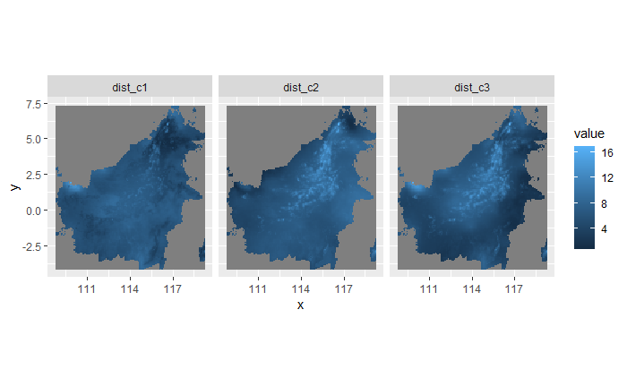

```r
ggR(unC2$map, 1:3, geom_raster = TRUE)
```

# 6 Extracting values

We can combine these PCA axes to then select our points of interest and see where they fall

```r
stackPCA <- brick(bio_PCA$map[[1:4]])
```

and extract the point values

```r
test <- extract(stackPCA, sample_pts)
test2 <- extract(bio_cropped, sample_pts)
```

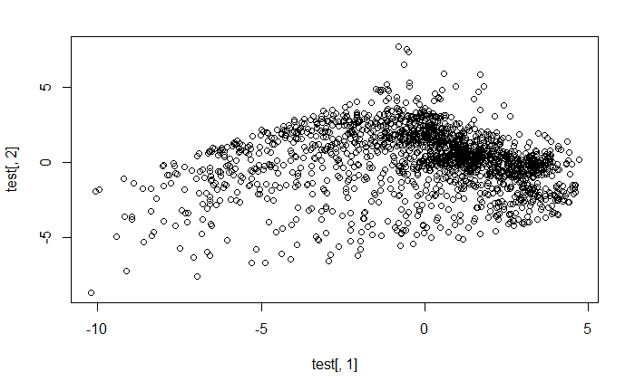

```r
plot(test[,1], test[,2])
```

Check these values

```r
sum(is.na(test2))
```

```
[1] 19
```

Some cells have NA values. let’s remove these before re-running the PCA manually

```r
test2.na.rm <- na.omit(test2)
```

```r
biopca2 <- dudi.pca(test2.na.rm[,-1], center = T, scale = T, scannf = F, nf = 4)
```

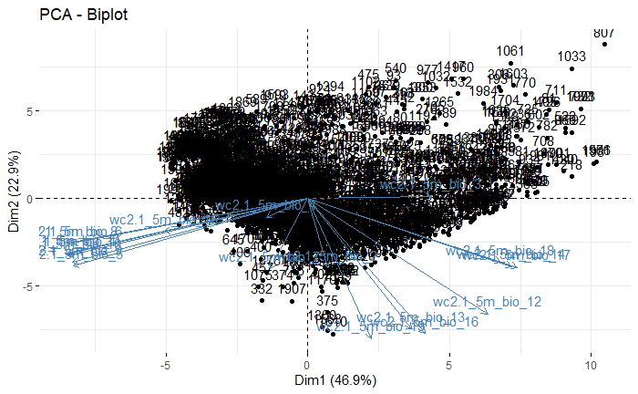

```r
fviz_pca(biopca2)
```

```r
get_eig(biopca2)
```

|  | eigenvalue | variance.percent | cumulative.variance.percent |
| --- | --- | --- | --- |
| Dim.1 | 8.9163679603 | 4.692825e+01 | 46.92825 |
| Dim.2 | 4.3460889814 | 2.287415e+01 | 69.80240 |
| Dim.3 | 2.5922603273 | 1.364348e+01 | 83.44588 |
| Dim.4 | 1.8845258171 | 9.918557e+00 | 93.36444 |
| Dim.5 | 0.5718005413 | 3.009477e+00 | 96.37391 |
| Dim.6 | 0.4336704945 | 2.282476e+00 | 98.65639 |
| Dim.7 | 0.0953289973 | 5.017316e-01 | 99.15812 |
| Dim.8 | 0.0827739696 | 4.356525e-01 | 99.59377 |
| Dim.9 | 0.0302575066 | 1.592500e-01 | 99.75302 |
| Dim.10 | 0.0176339366 | 9.281019e-02 | 99.84583 |

[output cut: 8 more lines]

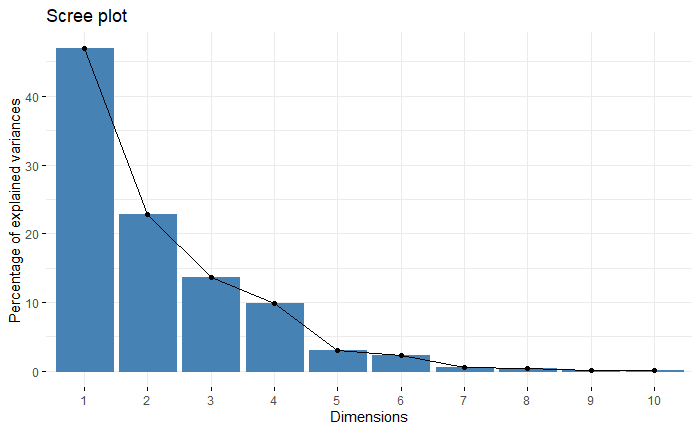

```r
fviz_eig(biopca2)
```

or a densityplot with an alpha hull contour for this we need to remove any duplicated values in our pca

```r
library(alphahull)
BIO_PCs <- biopca2$li[,1:2]
BIO_PCs_unique <- BIO_PCs[!duplicated(BIO_PCs),]
alpha_obj <- ashape(BIO_PCs_unique, alpha=2)
```

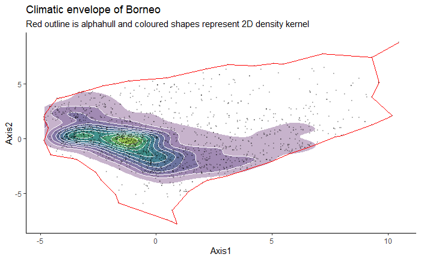

```r
ggplot(data=biopca2$li, aes(Axis1, Axis2)) +
  stat_density2d(aes(fill = after_stat(level)), geom = "polygon", colour="white", alpha =0.3) +
  geom_point(size=0.2,alpha=0.2) +
  geom_segment(data=data.frame(alpha_obj$edges), aes(x = x1, y = y1, xend = x2, yend = y2), color="red") +
  theme_classic() +
  scale_fill_viridis() +
  labs(title = "Climatic envelope of Borneo",
              subtitle = "Red outline is alphahull and coloured shapes represent 2D density kernel") +
  theme(legend.position = "none")
```

# 7 Classification

We can use the MClust package to make some density based clustering.

```r
library(mclust)
#Here I am using the first 3 axes only, but you can change this and see how it modifies the results
clusters <- Mclust(biopca2$li[,1:3])
```

```
fitting ...
```

```r
summary(clusters)
```

```
----------------------------------------------------
Gaussian finite mixture model fitted by EM algorithm
----------------------------------------------------

Mclust VVV (ellipsoidal, varying volume, shape, and orientation) model with 9 components:
```

|  | log-likelihood | n | df | BIC | ICL |
| --- | --- | --- | --- | --- | --- |
|  | -11333.01 | 1999 | 89 | -23342.46 | -24048.13 |

```
Clustering table:
  1   2   3   4   5   6   7   8   9
226 217 191 194 218 230 333 242 148
```

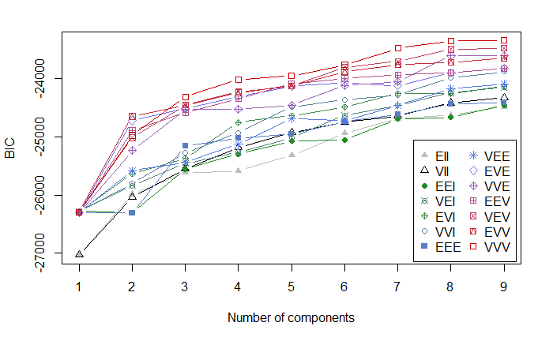

```r
plot(clusters, "BIC")
```

Seems like 9 clusters is the best option

Let’s plot these back onto the map

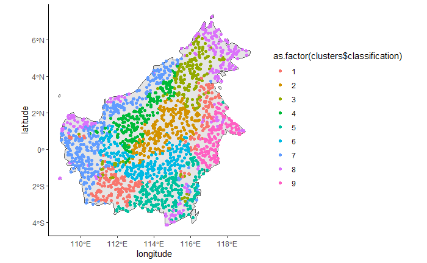

```r
ggplot() +
  geom_sf(data=Borneo_united) +
  geom_point(data = sample_pts[rownames(test2.na.rm),], aes(x=longitude, y=latitude, col=as.factor(clusters$classification))) +
  theme_classic()
```

Compare with the K-means we did earlier

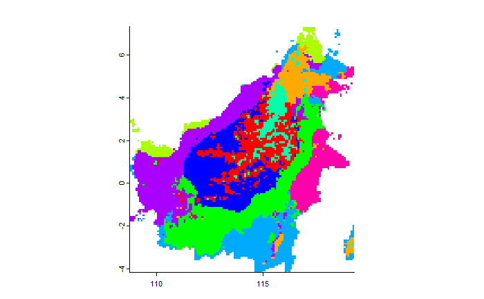

```r
plot(unC$map, col = colors, legend = FALSE, axes = T, box = FALSE)
```